# Stan for Bayesian time series analysis

For this lab, we will use [Stan](http://mc-stan.org/documentation/) for fitting models. These examples are primarily drawn from the Stan manual and previous code from this class.

A script with all the R code in the chapter can be downloaded here.

### Data and packages

You will need the **atsar** package we have written for fitting state-space time series models with Stan. This is hosted on Github [safs-timeseries](https://github.com/nwfsc-timeseries/atsar). Install using the **devtools** package.

```r
library(devtools)
# Windows users will likely need to set this
# Sys.setenv("R_REMOTES_NO_ERRORS_FROM_WARNINGS" = "true")
devtools::install_github("nwfsc-timeseries/atsar")
devtools::install_github("nwfsc-timeseries/tvvarss")
devtools::install_github("fate-ewi/bayesdfa")
```

In addition, you will need the **rstan**, **datasets**, **parallel** and **loo** packages. After installing, if needed, load the packages:

```r
library(atsar)
library(rstan)
library(loo)
```

Once you have Stan and **rstan** installed, optimize Stan on your machine:

```r
rstan_options(auto_write = TRUE)
options(mc.cores = parallel::detectCores())
```

For this lab, we will use a data set on airquality in New York from the **datasets** package. Load the data and create a couple new variables for future use.

```r
data(airquality, package="datasets")
Wind <- airquality$Wind # wind speed
Temp <- airquality$Temp # air temperature
```

## Linear regression

We’ll start with the simplest time series model possible: linear regression with only an intercept, so that the predicted values of all observations are the same. There are several ways we can write this equation. First, the predicted values can be written as $E[Y_{t}] = \beta x$, where $x=1$. Assuming that the residuals are normally distributed, the model linking our predictions to observed data is written as
$$y_t = \beta x + e_{t}, e_{t} \sim N(0,\sigma), x=1$$

An equivalent way to think about this model is that instead of the residuals as normally distributed with mean zero, we can think of the data $y_t$ as being drawn from a normal distribution with a mean of the intercept, and the same residual standard deviation:
$$Y_t \sim N(E[Y_{t}],\sigma)$$
Remember that in linear regression models, the residual error is interpreted as independent and identically distributed observation error.

To run this model using our package, we’ll need to specify the response and predictor variables. The covariate matrix with an intercept only is a matrix of 1s. To double check, you could always look at

```r
x <- model.matrix(lm(Temp~1))
```

Fitting the model using our function is done with this code,

```r
lm_intercept <- atsar::fit_stan(y = as.numeric(Temp), x = rep(1, length(Temp)),
  model_name = "regression")
```

Coarse summaries of `stanfit` objects can be examined by typing one of the following

```r
lm_intercept
# this is huge
summary(lm_intercept)
```

But to get more detailed output for each parameter, you have to use the `extract()` function,

```r
pars <- rstan::extract(lm_intercept)
names(pars)
```

```
[1] "beta"    "sigma"   "pred"    "log_lik" "lp__"
```

`extract()` will return the draws from the posterior for your parameters and any derived variables specified in your stan code. In this case, our model is
$$y_t = \beta \times 1 + e_t, e_t \sim N(0,\sigma)$$
so our estimated parameters are $\beta$ and $\sigma$. Our stan code computed the derived variables: predicted $y_t$ which is $\hat{y}_t = \beta \times 1$ and the log-likelihood. lp__ is the log posterior which is automatically returned.

We can then make basic plots or summaries of each of these parameters,

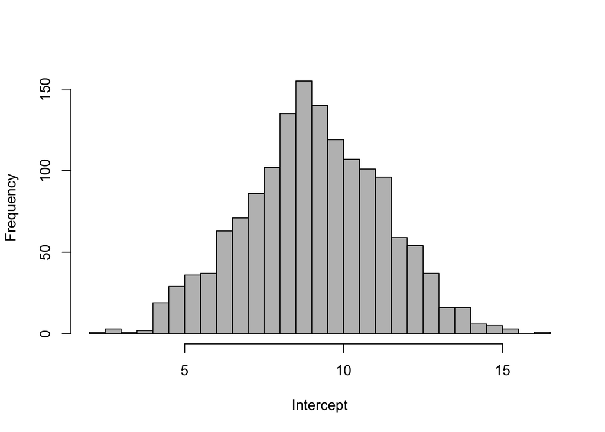

```r
hist(pars$beta, 40, col="grey", xlab="Intercept", main="")
```

```r
quantile(pars$beta, c(0.025,0.5,0.975))
```

```
     2.5%       50%     97.5%
 4.711553  9.046766 13.191865
```

One of the other useful things we can do is look at the predicted values of our model ($\hat{y}_t=\beta \times 1$) and overlay the data. The predicted values are *pars$pred*.

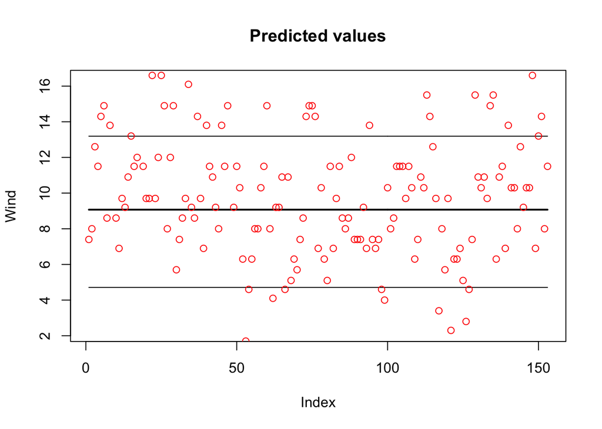

Data and predicted values for the linear regression model.

```r
plot(apply(pars$pred, 2, mean), main="Predicted values", lwd=2,
  ylab="Wind", ylim= c(min(pars$pred), max(pars$pred)), type="l")
lines(apply(pars$pred, 2, quantile,0.025))
lines(apply(pars$pred, 2, quantile,0.975))
points(Wind, col="red")
```

### Burn-in and thinning

To illustrate the effects of the burn-in/warmup period and thinning, we can re-run the above model, but for just 1 MCMC chain (the default is 3).

```r
lm_intercept <- atsar::fit_stan(y = Temp, x = rep(1, length(Temp)),
  model_name = "regression",
  mcmc_list = list(n_mcmc = 1000, n_burn = 1, n_chain = 1, n_thin = 1))
```

Here is a plot of the time series of `beta` with one chain and no burn-in. Based on visual inspection, when does the chain converge?

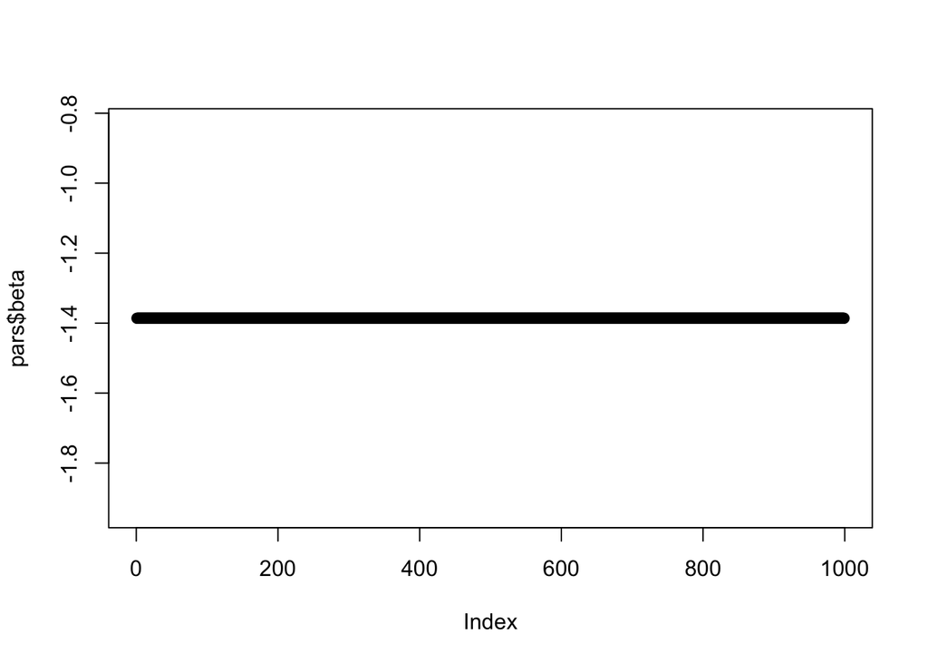

A time series of our posterior draws using one chain and no burn-in.

```r
pars <- rstan::extract(lm_intercept)
plot(pars$beta)
```

## Linear regression with correlated errors

In our first model, the errors were independent in time. We’re going to modify this to model autocorrelated errors. Autocorrelated errors are widely used in ecology and other fields – for a greater discussion, see Morris and Doak (2002) Quantitative Conservation Biology. To make the errors autocorrelated, we start by defining the error in the first time step, ${e}_{1} = y_{1} - \beta$. The expectation of ${Y_t}$ in each time step is then written as
$$E[{Y_t}] = \beta + \phi e_{t-1}$$

In addition to affecting the expectation, the correlation parameter $\phi$ also affects the variance of the errors, so that
$${ \sigma }^{ 2 }={ \psi }^{ 2 }\left( 1-{ \phi }^{ 2 } \right)$$
Like in our first model, we assume that the data follows a normal likelihood (or equivalently that the residuals are normally distributed), $y_t = E[Y_t] + e_t$, or $Y_t \sim N(E[{Y_t}], \sigma)$. Thus, it is possible to express the subsequent deviations as ${e}_{t} = {y}_{t} - E[{Y_t}]$, or equivalently as ${e}_{t} = {y}_{t} - \beta -\phi {e}_{t-1}$.

We can fit this regression with autocorrelated errors by changing the model name to ‘regression_cor’

```r
lm_intercept_cor <- atsar::fit_stan(y = Temp, x = rep(1, length(Temp)),
  model_name = "regression_cor",
  mcmc_list = list(n_mcmc = 1000, n_burn = 1, n_chain = 1, n_thin = 1))
```

## Random walk model

All of the previous three models can be interpreted as observation error models. Switching gears, we can alternatively model error in the state of nature, creating process error models. A simple process error model that many of you may have seen before is the random walk model. In this model, the assumption is that the true state of nature (or latent states) are measured perfectly. Thus, all uncertainty is originating from process variation (for ecological problems, this is often interpreted as environmental variation). For this simple model, we’ll assume that our process of interest (in this case, daily wind speed) exhibits no daily trend, but behaves as a random walk.

$$y_t = y_{t-1} + e_{t}$$

And the ${e}_{t} \sim N(0, \sigma)$. Remember back to the autocorrelated model (or MA(1) models) that we assumed that the errors $e_t$ followed a random walk. In contrast, this model assumes that the errors are independent, but that the state of nature follows a random walk. Note also that this model as written doesn’t include a drift term (this can be turned on / off using the `est_drift` argument).

We can fit the random walk model using argument `model_name = 'rw'` passed to the `fit_stan()` function.

```r
rw <- atsar::fit_stan(y = Temp, est_drift = FALSE, model_name = "rw")
```

## Autoregressive models

A variation of the random walk model described previously is the autoregressive time series model of order 1, AR(1). This model is essentially the same as the random walk model but it introduces an estimated coefficient, which we will call $\phi$. The parameter $\phi$ controls the degree to which the random walk reverts to the mean – when $\phi$ = 1, the model is identical to the random walk, but at smaller values, the model will revert back to the mean (which in this case is zero). Also, $\phi$ can take on negative values, which we’ll discuss more in future lectures. The math to describe the AR(1) model is:
$$y_t = \phi y_{t-1} + e_{t}$$
.

The `fit_stan()` function can fit higher order AR models, but for now we just want to fit an AR(1) model and make a histogram of phi.

```r
ar1 <- atsar::fit_stan(y = Temp, x = matrix(1, nrow = length(Temp), ncol = 1),
  model_name = "ar", est_drift=FALSE, P = 1)
```

## Univariate state-space models

At this point, we’ve fit models with observation or process error, but we haven’t tried to estimate both simultaneously. We will do so here, and introduce some new notation to describe the process model and observation model. We use the notation ${x_t}$ to denote the latent state or state of nature (which is unobserved) at time $t$ and ${y_t}$ to denote the observed data. For introductory purposes, we’ll make the process model autoregressive (similar to our AR(1) model),

$$x_{t} = \phi x_{t-1} + e_{t}, e_{t} \sim N(0,q)$$

For the process model, there are a number of ways to parameterize the first ‘state’, and we’ll talk about this more in the class, but for the sake of this model, we’ll place a vague weakly informative prior on $x_1$, $x_1 \sim N(0, 0.01)$.Second, we need to construct an observation model linking the estimate unseen states of nature $x_t$ to the data $y_t$. For simplicitly, we’ll assume that the observation errors are indepdendent and identically distributed, with no observation component. Mathematically, this model is
$$Y_t \sim N(x_t, r)$$
In the two above models, we’ll refer to $q$ as the standard deviation of the process variance and $r$ as the standard deviation of the observation error variance

We can fit the state-space AR(1) and random walk models using the `fit_stan()` function:

```r
ss_ar <- atsar::fit_stan(y = Temp, est_drift=FALSE, model_name = "ss_ar")
ss_rw <- atsar::fit_stan(y = Temp, est_drift=FALSE, model_name = "ss_rw")
```

## Dynamic factor analysis

First load the plankton dataset from the **MARSS** package.

```r
 library(MARSS)
 data(lakeWAplankton, package="MARSS")
 # we want lakeWAplanktonTrans, which has been transformed
 # so the 0s are replaced with NAs and the data z-scored
 dat <- lakeWAplanktonTrans
 # use only the 10 years from 1980-1989
 plankdat <- dat[dat[,"Year"]>=1980 & dat[,"Year"]<1990,]
 # create vector of phytoplankton group names
 phytoplankton <- c("Cryptomonas", "Diatoms", "Greens",
                   "Unicells", "Other.algae")
 # get only the phytoplankton
 dat.spp.1980 <- t(plankdat[,phytoplankton])
 # z-score the data since we subsetted time
 dat.spp.1980 <- dat.spp.1980-apply(dat.spp.1980,1,mean,na.rm=TRUE)
 dat.spp.1980 <- dat.spp.1980/sqrt(apply(dat.spp.1980,1,var,na.rm=TRUE))
 #check our z-score
 apply(dat.spp.1980,1,mean,na.rm=TRUE)
```

```
  Cryptomonas       Diatoms        Greens      Unicells   Other.algae
 4.951913e-17 -1.337183e-17  3.737694e-18 -5.276451e-18  4.365269e-18
```

```r
 apply(dat.spp.1980,1,var,na.rm=TRUE)
```

```
Cryptomonas     Diatoms      Greens    Unicells Other.algae
          1           1           1           1           1
```

Plot the data.

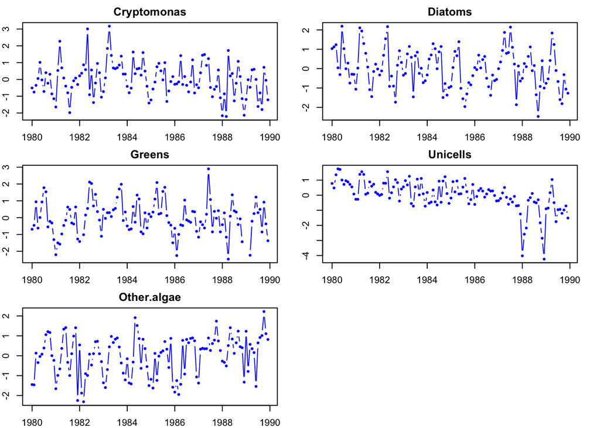

Phytoplankton data.

```r
#make into ts since easier to plot
dat.ts <- ts(t(dat.spp.1980),frequency=12, start=c(1980,1))
par(mfrow=c(3,2),mar=c(2,2,2,2))
for(i in 1:5)
  plot(dat.ts[,i], type="b",
       main=colnames(dat.ts)[i],col="blue",pch=16)
```

Run a 3 trend model on these data.

```r
mod_3 <- bayesdfa::fit_dfa(y = dat.spp.1980, num_trends=3, chains=1, iter=1000)
```

Rotate the estimated trends and look at what it produces.

```r
rot <- bayesdfa::rotate_trends(mod_3)
names(rot)
```

```
[1] "Z_rot"         "trends"        "Z_rot_mean"    "Z_rot_median"
[5] "trends_mean"   "trends_median" "trends_lower"  "trends_upper"
```

Plot the estimate of the trends.

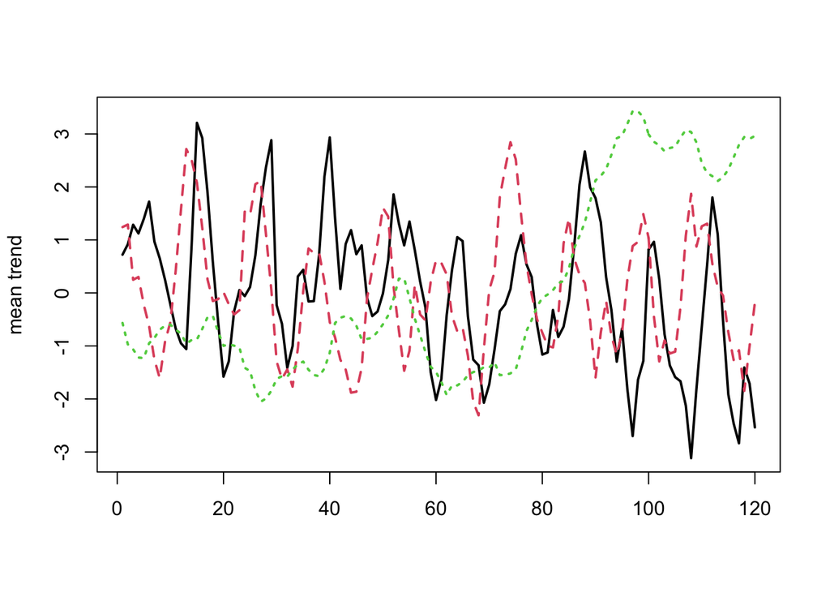

Trends.

```r
matplot(t(rot$trends_mean),type="l",lwd=2,ylab="mean trend")
```

### Using leave one out cross-validation to select models

We will fit multiple DFA with different numbers of trends and use leave one out (LOO) cross-validation to choose the best model.

```r
mod_1 = bayesdfa::fit_dfa(y = dat.spp.1980, num_trends=1, iter=1000, chains=1)
mod_2 = bayesdfa::fit_dfa(y = dat.spp.1980, num_trends=2, iter=1000, chains=1)
mod_3 = bayesdfa::fit_dfa(y = dat.spp.1980, num_trends=3, iter=1000, chains=1)
mod_4 = bayesdfa::fit_dfa(y = dat.spp.1980, num_trends=4, iter=1000, chains=1)
#mod_5 = bayesdfa::fit_dfa(y = dat.spp.1980, num_trends=5)
```

We will compute the Leave One Out Information Criterion (LOOIC) using the **loo** package. Like AIC, lower is better.

```r
loo(mod_1)$estimates["looic", "Estimate"]
```

```
[1] 1612.453
```

Table of the LOOIC values:

```r
looics = c(
  loo(mod_1)$estimates["looic","Estimate"],
  loo(mod_2)$estimates["looic","Estimate"],
  loo(mod_3)$estimates["looic","Estimate"],
  loo(mod_4)$estimates["looic","Estimate"]
  #loo::loo(loo::extract_log_lik(mod_5))$estimates["looic","Estimate"]
  )
looic.table <- data.frame(trends=1:4, LOOIC=looics)
looic.table
```

```
  trends    LOOIC
1      1 1612.453
2      2 1540.119
3      3 1484.842
4      4 1459.882
```

## Uncertainty intervals on states

We will look at the effect of missing data on the uncertainty intervals on estimates states using a DFA on the harbor seal dataset.

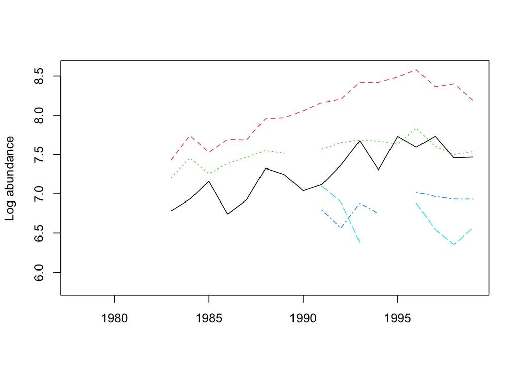

```r
data(harborSealWA, package = "MARSS")
# the first column is year
matplot(harborSealWA[, 1], harborSealWA[, -1], type = "l", ylab = "Log abundance",
    xlab = "")
```

Assume they are all observing a single trend.

```r
seal.mod <- bayesdfa::fit_dfa(y = t(harborSealWA[, -1]), num_trends = 1,
    chains = 1, iter = 1000)
```

```r
pars <- rstan::extract(seal.mod$model)
```

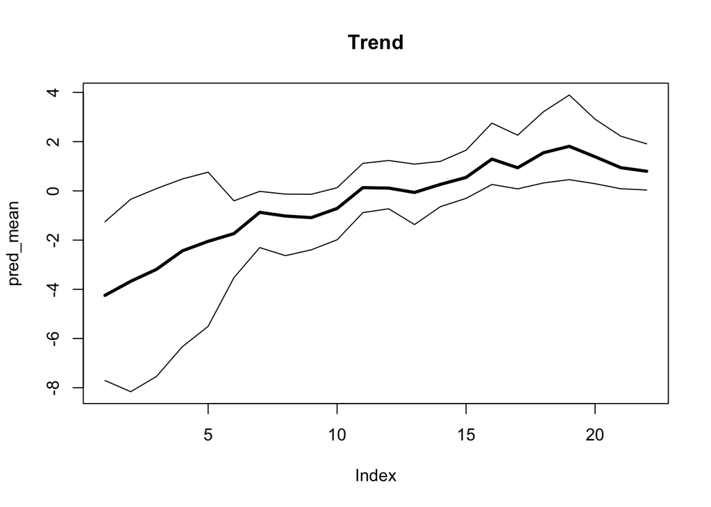

Estimated states and 95 percent credible intervals.

```r
pred_mean <- c(apply(pars$x, c(2, 3), mean))
pred_lo <- c(apply(pars$x, c(2, 3), quantile, 0.025))
pred_hi <- c(apply(pars$x, c(2, 3), quantile, 0.975))

plot(pred_mean, type = "l", lwd = 3, ylim = range(c(pred_mean,
    pred_lo, pred_hi)), main = "Trend")
lines(pred_lo)
lines(pred_hi)
```

## NEON EFI Aquatics Challenge

The data for the aquatics challenge comes from a NEON site at Lake Barco (Florida). More about the data and challenge is [here](https://ecoforecast.org/efi-rcn-forecast-challenges/) and the Github repository for getting all the necessary data is [here](https://github.com/eco4cast/neon4cast-aquatics).

We can pull in the data with the code from the challenge

```r
library(tidyverse)
library(lubridate)
```

```r
library(rstan)
library(ggplot2)
# This taken from code on NEON aquatics challenge
targets <- read_csv("aquatics-targets.csv.gz", guess_max = 10000)
site_data_var <- targets %>% filter(siteID == "BARC")

# This is key here - I added the forecast horizon on the end
# of the data for the forecast period
full_time <- tibble(time = seq(min(site_data_var$time), max(site_data_var$time),
    by = "1 day"))

# Join the full time with the site_data_var so there aren't
# gaps in the time column
site_data_var <- left_join(full_time, site_data_var) %>% dplyr::rename(date = time)
site_data_var$year = year(site_data_var$date)
site_data_var$cal_day = yday(site_data_var$date)

saveRDS(site_data_var, "neon_barc.rds")
```

Familiarize yourself with the oxygen and temperature data from Lake Barco

Question: what sort of models do you think would be good candidates for forecasting?

## NEON EFI Aquatics Challenge

Before modeling temperature and oxygen jointly, we’ll start working with just the oxygen data alone.

We’ll just with just a AR(p) state space model. The Lake Barco data has associated standard errors with the oxygen data, so we’ll use that as a known observation error (rather than estimating that variance parameter, in our previous work).

A script that describes the model is called `model_01.stan`. This should be familiar, following from the `atsar` code with a couple modifications. First, Stan doesn’t like NAs being passed in as data, and we’ve had to do some indexing to avoid that. Second, notice that the model is flexible and can be used to fit models with any numbers of lags.

To get the data prepped for Stan, we need to do a few things. First, specify the lag and forecast horizon

```r
# Now data is ready for running our Stan models
data <- readRDS("neon_barc.rds")
data$indx = seq(1, nrow(data))
n_forecast <- 7
n_lag <- 1
```

Next, we’ll drop observations with missing oxygen. If you wanted to do some validation, we could also split the data into a training and test set.

```r
# As a first model, we'll just work with modeling oxygen
o2_dat <- dplyr::filter(data, !is.na(oxygen))

# split the test and training data
last_obs <- max(data$indx) - n_forecast
o2_train <- dplyr::filter(o2_dat, indx <= last_obs)
test = dplyr::filter(data, indx > last_obs)

o2_x = o2_train$indx
o2_y = o2_train$oxygen
o2_sd = o2_train$oxygen_sd
n_o2 = nrow(o2_train)
```

Remember that the Stan data needs to be in a list,

```r
stan_data = list(n = last_obs, n_o2 = n_o2, n_lag = n_lag, n_forecast = n_forecast,
    o2_x = o2_x, o2_y = o2_y, o2_sd = o2_sd)
```

Finally we can compile the model. If we wanted to do fully Bayesian estimates, we could do that with

```r
fit <- stan(file = "model_01.stan", data = stan_data)
```

Try fitting the Bayesian model with a short chain length (maybe 1000 iterations) and 1 MCMC chain.

But because we’re interested in doing this quickly, and running the model a bunch of times, we’ll try Stan’s optimizing function for MAP estimation.

```r
m <- stan_model(file = "model_01.stan")
o2_model <- rstan::optimizing(m, data = stan_data, hessian = TRUE)
```

Let’s extract predictions from the fitted object,

```r
data$pred = o2_model$par[grep("pred", names(o2_model$par))]
ggplot(data, aes(date, pred)) + geom_line() + geom_point(aes(date,
    oxygen), col = "red", alpha = 0.5)
```

Question how do we evaluate predictions? We’ll talk about that more next week, but for today we can think about it as RMSE(observations,predictions)

Question: modify the code above (just on the R side, not Stan) to fit a lag-2 or lag-3 model. Are the predictions similar?

## NEON EFI Aquatics Challenge

In generating forecasts, it’s often a good idea to use multiple training / test sets. One question with this challenge is what’s the best lag (or order of AR model) for generating forecasts? Starting with lag-1, we can evaluate the effects of different lags by starting at some point in the dataset (e.g. using 50% of the observations), and generate and evaluate forecasts. We then iterate, adding a day of data, generating and evaluating forecasts, and repeating through the rest of the data. [An alternative approach would be to adopt a moving window, where each prediction would be based on the same number of historical data points].

```r
create_stan_data = function(data, last_obs, n_forecast, n_lag) {
    o2_test <- dplyr::filter(data, indx %in% seq(last_obs + 1,
        (last_obs + n_forecast)))

    o2_train <- dplyr::filter(data, indx <= last_obs, !is.na(oxygen))
    o2_x = o2_train$indx
    o2_y = o2_train$oxygen
    o2_sd = o2_train$oxygen_sd
    n_o2 = nrow(o2_train)

    stan_data = list(n = last_obs, n_o2 = n_o2, n_lag = n_lag,
        n_forecast = n_forecast, o2_x = o2_x, o2_y = o2_y, o2_sd = o2_sd)

    return(list(train = o2_train, stan_data = stan_data, test = o2_test))
}
```

Now we can try iterating over sets of data with a lag 1 model

```r
n_forecast <- 7
n_lag <- 1
rmse <- NA
for (i in 500:(nrow(data) - n_lag)) {
    dat_list = create_stan_data(data, last_obs = i, n_forecast = n_forecast,
        n_lag = n_lag)

    # fit the model. opimizing can be sensitive to starting
    # values, so let's try
    best_map = -1e+100
    for (j in 1:10) {
        test_fit <- rstan::optimizing(m, data = dat_list$stan_data)
        if (test_fit$value > best_map) {
            fit <- test_fit
            best_map <- test_fit$value
        }
    }
    if (fit$return_code == 0) {
        # extract forecasts
        pred = fit$par[grep("forecast", names(fit$par))]

        # evaluate predictions
        rmse[i] <- sqrt(mean((dat_list$test$oxygen - pred)^2,
            na.rm = T))

    }
}
```

## NEON EFI Aquatics Challenge

So far, these models have only included oxygen. We can easily bring in the temperature data, which has it’s own standard error associated with it. We can set up a null model modeling temperature and oxygen independently, with different lags allowed

First we have to modify our data function to also generate temperature data.

```r
create_stan_data = function(data, last_obs, n_forecast, n_lag_o2,
    n_lag_temp) {
    # create test data
    o2_test <- dplyr::filter(data, indx %in% seq(last_obs + 1,
        (last_obs + n_forecast)))
    temp_test <- dplyr::filter(data, indx %in% seq(last_obs +
        1, (last_obs + n_forecast)))

    o2_train <- dplyr::filter(data, indx <= last_obs, !is.na(oxygen))
    o2_x = o2_train$indx
    o2_y = o2_train$oxygen
    o2_sd = o2_train$oxygen_sd
    n_o2 = nrow(o2_train)

    temp_train <- dplyr::filter(data, indx <= last_obs, !is.na(temperature))
    temp_x = temp_train$indx
    temp_y = temp_train$temperature
    temp_sd = temp_train$temperature_sd
    n_temp = nrow(temp_train)

    stan_data = list(n = last_obs, n_lag_o2 = n_lag_o2, n_lag_temp = n_lag_temp,
        n_forecast = n_forecast, n_o2 = n_o2, o2_x = o2_x, o2_y = o2_y,
        o2_sd = o2_sd, n_temp = n_temp, temp_x = temp_x, temp_y = temp_y,
        temp_sd = temp_sd)

    return(list(o2_train = o2_train, temp_train = temp_train,
        stan_data = stan_data, o2_test = o2_test, temp_test = temp_test))
}
```

```r
m <- stan_model(file = "model_02.stan")
```

```r
# Now we can try iterating over sets of data with a lag 1
# model
n_forecast <- 7
n_lag <- 1
rmse <- NA
for (i in 500:(nrow(data) - n_lag)) {
    dat_list = create_stan_data(data, last_obs = i, n_forecast = n_forecast,
        n_lag_o2 = n_lag, n_lag_temp = n_lag)

    # fit the model. opimizing can be sensitive to starting
    # values, so let's try
    best_map = -1e+100
    for (j in 1:10) {
        test_fit <- rstan::optimizing(m, data = dat_list$stan_data)
        if (test_fit$value > best_map) {
            fit <- test_fit
            best_map <- test_fit$value
        }
    }

    # extract forecasts
    o2_pred = fit$par[grep("o2_forecast", names(fit$par))]
    temp_pred = fit$par[grep("temp_forecast", names(fit$par))]

    pred = c(o2_pred, temp_pred)
    obs = c(dat_list$o2_test$oxygen, dat_list$temp_test$temperature)
    # evaluate predictions
    rmse[i] <- sqrt(mean((obs - pred)^2, na.rm = T))
    print(rmse)
}
```

Question: why do the future predictions of either temp or oxygen sometimes fall to 0, and appear to do poorly?

Question: modify the script above to loop over various oxygen and temperature lags. Using a subset of data, say observations 500:800, which combination yields the best predictions?